# RNAseq, multispecies killifish osmotic challenge

Lisa K. Johnson

2019-02-16

# 1 PCA, all counts

This is the PCA with all counts, not filtered. The dimensions of the counts table are listed below. Row=genes, Columns=samples

```r
# normal full counts
x <- data.matrix(counts)
dim(x)
```

```
## [1] 30466   128
```

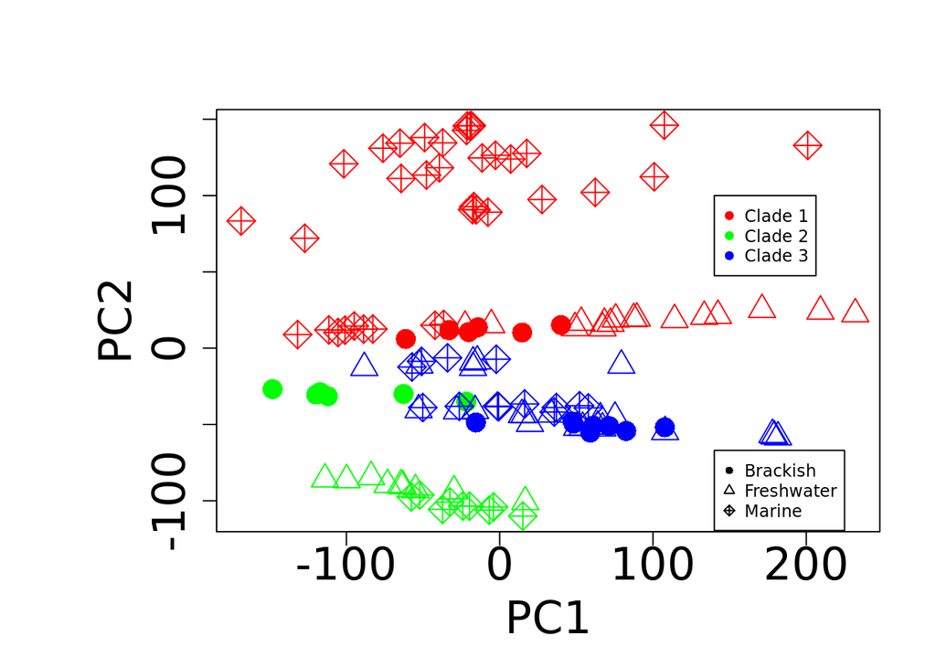

```r
x <- x+1
log_x<-log(x)
names<-colnames(log_x)
pca = prcomp(t(log_x))
#summary(pca)
fac = factor(nativephysiology)
colours = function(vec){
  cols=rainbow(length(unique(vec)))
  return(cols[as.numeric(as.factor(vec))])}
mar.default <- c(5,4,4,2) + 0.1
par(mar = mar.default + c(0, 4, 0, 0))
plot(pca$x[,1:2],
     col=colours(clade),
     pch = c(16, 2, 9)[as.numeric(as.factor(nativephysiology))],
     cex=2,
     xlab="PC1",
     ylab="PC2",
     cex.lab=2,
     cex.axis = 2)
legend(140,100,legend=c("Clade 1","Clade 2","Clade 3"),col=rainbow(length(unique(clade))),cex=0.75, pch=19)
legend(140,-67,legend=c("Brackish","Freshwater","Marine"),cex=0.75,pch=c(16, 2, 9))
```

# 2 Filtering counts

The following shows the dimensions of the dataframe when we filter out genes with low counts.

All 128 samples must have a count of at least 10:

```r
filter <- rownames(counts[rowSums(counts >= 10) >= 128,])
filtered_counts <- counts[filter,]
dim(filtered_counts)
```

```
## [1] 5899  128
```

All 128 samples must have a count of at least 1:

```r
# filtering counts
filter <- rownames(counts[rowSums(counts >= 1) >= 128,])
filtered_counts <- counts[filter,]
dim(filtered_counts)
```

```
## [1] 6262  128
```

All 128 samples have a count of at least 0.1:

```r
filter <- rownames(counts[rowSums(counts >= 0.1) >= 128,])
filtered_counts <- counts[filter,]
dim(filtered_counts)
```

```
## [1] 6263  128
```

All 128 samples have a count of at least 0.01:

```r
filter <- rownames(counts[rowSums(counts >= 0.01) >= 128,])
filtered_counts <- counts[filter,]
dim(filtered_counts)
```

```
## [1] 6263  128
```

```r
filtered_counts_128_0.01 <- filtered_counts
```

At least 100 samples have a count of at least 10:

```r
filter <- rownames(counts[rowSums(counts >= 10) >= 100,])
filtered_counts <- counts[filter,]
dim(filtered_counts)
```

```
## [1] 14167   128
```

At least 100 samples have a count of at least 1:

```r
filter <- rownames(counts[rowSums(counts >= 1) >= 100,])
filtered_counts <- counts[filter,]
dim(filtered_counts)
```

```
## [1] 14878   128
```

At least 100 samples have a count of at least 0.1:

```r
filter <- rownames(counts[rowSums(counts >= 0.1) >= 100,])
filtered_counts <- counts[filter,]
dim(filtered_counts)
```

```
## [1] 14879   128
```

At least 100 samples have a count of at least 0.01:

```r
filter <- rownames(counts[rowSums(counts >= 0.01) >= 100,])
filtered_counts <- counts[filter,]
dim(filtered_counts)
```

```
## [1] 14879   128
```

```r
filtered_counts_100_0.01 <- filtered_counts
```

At least 64 samples have a count of at least 10:

```r
filter <- rownames(counts[rowSums(counts >= 10) >= 64,])
filtered_counts <- counts[filter,]
dim(filtered_counts)
```

```
## [1] 18492   128
```

At least 64 samples have a count of at least 1:

```r
filter <- rownames(counts[rowSums(counts >= 1) >= 64,])
filtered_counts <- counts[filter,]
dim(filtered_counts)
```

```
## [1] 19477   128
```

At least 64 samples have a count of at least 0.1:

```r
filter <- rownames(counts[rowSums(counts >= 0.1) >= 64,])
filtered_counts <- counts[filter,]
dim(filtered_counts)
```

```
## [1] 19480   128
```

At least 64 samples have a count of at least 0.01:

```r
filter <- rownames(counts[rowSums(counts >= 0.01) >= 64,])
filtered_counts <- counts[filter,]
dim(filtered_counts)
```

```
## [1] 19480   128
```

```r
filtered_counts_64_0.01 <- filtered_counts
```

## 2.1 PCA

At least 128 samples with a count of at least 0.01:

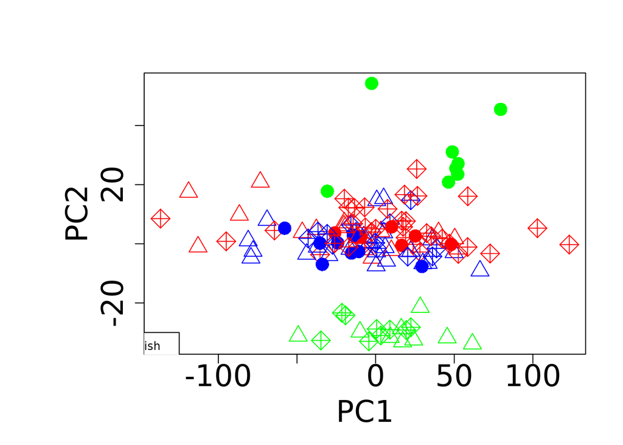

```r
#filtered_counts_64_0.01
#filtered_counts_100_0.01
#filtered_counts_128_0.01
# PCA 1
x <- data.matrix(filtered_counts_128_0.01)
x <- x+1
log_x<-log(x)
names<-colnames(log_x)
pca = prcomp(t(log_x))
fac = factor(nativephysiology)
colours = function(vec){
  cols=rainbow(length(unique(vec)))
  return(cols[as.numeric(as.factor(vec))])}
mar.default <- c(5,4,4,2) + 0.1
par(mar = mar.default + c(0, 4, 0, 0))
plot(pca$x[,1:2],
     col=colours(clade),
     pch = c(16, 2, 9)[as.numeric(as.factor(nativephysiology))],
     cex=2,
     xlab="PC1",
     ylab="PC2",
     cex.lab=2,
     cex.axis = 2)
legend(-180,100,legend=c("Clade 1","Clade 2","Clade 3"),col=rainbow(length(unique(clade))),cex=0.75, pch=19)
legend(-180,-30,legend=c("Brackish","Freshwater","Marine"),cex=0.75,pch=c(16, 2, 9))
```

At least 100 samples with a count of at least 0.01:

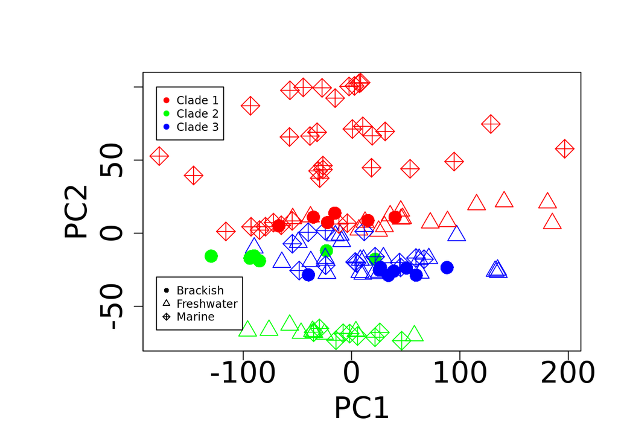

```r
# PCA 2
x <- data.matrix(filtered_counts_100_0.01)
x <- x+1
log_x<-log(x)
names<-colnames(log_x)
pca = prcomp(t(log_x))
fac = factor(nativephysiology)
colours = function(vec){
  cols=rainbow(length(unique(vec)))
  return(cols[as.numeric(as.factor(vec))])}
mar.default <- c(5,4,4,2) + 0.1
par(mar = mar.default + c(0, 4, 0, 0))
plot(pca$x[,1:2],
     col=colours(clade),
     pch = c(16, 2, 9)[as.numeric(as.factor(nativephysiology))],
     cex=2,
     xlab="PC1",
     ylab="PC2",
     cex.lab=2,
     cex.axis = 2)
legend(-180,100,legend=c("Clade 1","Clade 2","Clade 3"),col=rainbow(length(unique(clade))),cex=0.75, pch=19)
legend(-180,-30,legend=c("Brackish","Freshwater","Marine"),cex=0.75,pch=c(16, 2, 9))
```

At least 64 samples with a count of at least 0.01:

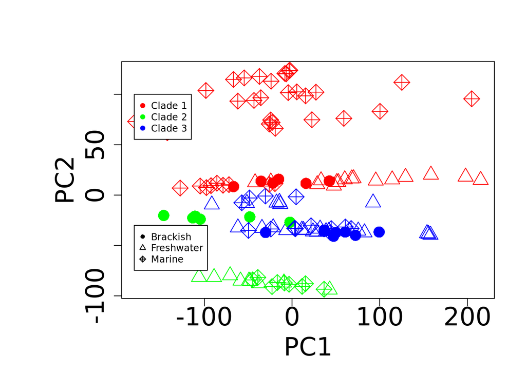

```r
# PCA 3
x <- data.matrix(filtered_counts_64_0.01)
x <- x+1
log_x<-log(x)
names<-colnames(log_x)
pca = prcomp(t(log_x))
fac = factor(nativephysiology)
colours = function(vec){
  cols=rainbow(length(unique(vec)))
  return(cols[as.numeric(as.factor(vec))])}
mar.default <- c(5,4,4,2) + 0.1
par(mar = mar.default + c(0, 4, 0, 0))
plot(pca$x[,1:2],
     col=colours(clade),
     pch = c(16, 2, 9)[as.numeric(as.factor(nativephysiology))],
     cex=2,
     xlab="PC1",
     ylab="PC2",
     cex.lab=2,
     cex.axis = 2)
legend(-180,100,legend=c("Clade 1","Clade 2","Clade 3"),col=rainbow(length(unique(clade))),cex=0.75, pch=19)
legend(-180,-30,legend=c("Brackish","Freshwater","Marine"),cex=0.75,pch=c(16, 2, 9))
```

# 3 DESeq2 analysis

## 3.1 Design

```r
cols<-colnames(filtered_counts)
ExpDesign <- data.frame(row.names=cols, condition=condition, species = species, clade=clade,species_condition=species_condition,species_clade = species_clade)
ExpDesign
```

|  | condition | species | clade | species_condition | species_clade |
| --- | --- | --- | --- | --- | --- |
| F_sciadicus_BW_1.quant | 15_ppt | F_sciadicus | Clade3 | F_sciadicus_15_ppt | Clade3_F_sciadicus |
| F_sciadicus_FW_1.quant | 0.2_ppt | F_sciadicus | Clade3 | F_sciadicus_0.2_ppt | Clade3_F_sciadicus |
| F_sciadicus_FW_2.quant | 0.2_ppt | F_sciadicus | Clade3 | F_sciadicus_0.2_ppt | Clade3_F_sciadicus |
| F_sciadicus_transfer_1.quant | transfer | F_sciadicus | Clade3 | F_sciadicus_transfer | Clade3_F_sciadicus |
| F_rathbuni_BW_1.quant | 15_ppt | F_rathbuni | Clade1 | F_rathbuni_15_ppt | Clade1_F_rathbuni |
| F_rathbuni_BW_2.quant | 15_ppt | F_rathbuni | Clade1 | F_rathbuni_15_ppt | Clade1_F_rathbuni |
| F_rathbuni_BW_3.quant | 15_ppt | F_rathbuni | Clade1 | F_rathbuni_15_ppt | Clade1_F_rathbuni |
| F_rathbuni_FW_1.quant | 0.2_ppt | F_rathbuni | Clade1 | F_rathbuni_0.2_ppt | Clade1_F_rathbuni |
| F_rathbuni_FW_2.quant | 0.2_ppt | F_rathbuni | Clade1 | F_rathbuni_0.2_ppt | Clade1_F_rathbuni |
| F_rathbuni_FW_3.quant | 0.2_ppt | F_rathbuni | Clade1 | F_rathbuni_0.2_ppt | Clade1_F_rathbuni |

[output cut: 118 more lines]

Clade1_F_catanatus and 0.2 ppt are reference levels for comparison.

```
m1 <- model.matrix(~condition + species_clade + species_clade:condition,ExpDesign)
```